# Final Project Report

Paula Buitrago

05-17-2025

### Introduction:

For my final project, I chose to answer the question: **Do NO2 levels differ significantly between the Upper West Side and Queens Village in New York?** I selected this topic because poorer or historically marginalized communities, like Queens village, often experience worse environmental conditions, which can reflect systematic inequality. Residents exposed to high NO2 levels could face health risks and would need targeted public health aid. This evidence could serve as an incentive to add green zones, rerouting traffic, or installing air monitoring stations in affected areas.

To answer my question, I used the *Air Quality* dataset found in data.gov through the NYC Open Data. It provides public access to detailed air monitoring records collected across various locations in New York from 2009-2023. This data can be accessed though the following link: https://catalog.data.gov/dataset/air-quality. The dataset contains 18,862 observations and 12 variables, with each row representing an air quality measurement taken at a specific time and location. Among the variables included are “Name” (the pollutant type and health impact), “Data.Value” (the recorded concentration), Geo.Place.Name (the neighborhood where the reading was taken), and “Measure.Info” (the units of measurement, such as ppb).

### Data Analysis:

```r
library(tidyverse)
air_data <- read.csv("Air_Quality.csv")

head(air_data)
```

```
##   Unique.ID Indicator.ID                   Name Measure Measure.Info
## 1    336867          375 Nitrogen dioxide (NO2)    Mean          ppb
## 2    336741          375 Nitrogen dioxide (NO2)    Mean          ppb
## 3    550157          375 Nitrogen dioxide (NO2)    Mean          ppb
## 4    412802          375 Nitrogen dioxide (NO2)    Mean          ppb
## 5    412803          375 Nitrogen dioxide (NO2)    Mean          ppb
## 6    412676          375 Nitrogen dioxide (NO2)    Mean          ppb
##   Geo.Type.Name Geo.Join.ID                    Geo.Place.Name
## 1            CD         407     Flushing and Whitestone (CD7)
## 2            CD         107             Upper West Side (CD7)
## 3            CD         414 Rockaway and Broad Channel (CD14)
## 4            CD         407     Flushing and Whitestone (CD7)
## 5            CD         407     Flushing and Whitestone (CD7)
## 6            CD         107             Upper West Side (CD7)
##           Time.Period Start_Date Data.Value Message
## 1      Winter 2014-15 12/01/2014      23.97      NA
## 2      Winter 2014-15 12/01/2014      27.42      NA
## 3 Annual Average 2017 01/01/2017      12.55      NA
## 4      Winter 2015-16 12/01/2015      22.63      NA
## 5         Summer 2016 06/01/2016      14.00      NA
## 6      Winter 2015-16 12/01/2015      26.43      NA
```

```r
tail(air_data)
```

```
##       Unique.ID Indicator.ID                   Name Measure Measure.Info
## 18857    336740          375 Nitrogen dioxide (NO2)    Mean          ppb
## 18858    165993          375 Nitrogen dioxide (NO2)    Mean          ppb
## 18859    338255          386             Ozone (O3)    Mean          ppb
## 18860    651029          386             Ozone (O3)    Mean          ppb
## 18861    667628          375 Nitrogen dioxide (NO2)    Mean          ppb
## 18862    167586          375 Nitrogen dioxide (NO2)    Mean          ppb
##       Geo.Type.Name Geo.Join.ID                        Geo.Place.Name
## 18857            CD         107                 Upper West Side (CD7)
## 18858            CD         207 Kingsbridge Heights and Bedford (CD7)
## 18859            CD         107                 Upper West Side (CD7)
## 18860            CD         307                     Sunset Park (CD7)
## 18861            CD         207 Kingsbridge Heights and Bedford (CD7)
## 18862            CD         207 Kingsbridge Heights and Bedford (CD7)
##               Time.Period Start_Date Data.Value Message
## 18857         Summer 2015 06/01/2015      19.77      NA
## 18858      Winter 2012-13 12/01/2012      25.78      NA
## 18859         Summer 2015 06/01/2015      28.13      NA
## 18860         Summer 2019 06/01/2019      28.78      NA
## 18861      Winter 2019-20 12/01/2019      23.68      NA
## 18862 Annual Average 2010 12/01/2009      23.77      NA
```

```r
dim(air_data)
```

```
## [1] 18862    12
```

```r
str(air_data)
```

```
## 'data.frame':    18862 obs. of  12 variables:
##  $ Unique.ID     : int  336867 336741 550157 412802 412803 412676 412677 603044 412804 825832 ...
##  $ Indicator.ID  : int  375 375 375 375 375 375 375 375 375 375 ...
##  $ Name          : chr  "Nitrogen dioxide (NO2)" "Nitrogen dioxide (NO2)" "Nitrogen dioxide (NO2)" "Nitrogen dioxide (NO2)" ...
##  $ Measure       : chr  "Mean" "Mean" "Mean" "Mean" ...
##  $ Measure.Info  : chr  "ppb" "ppb" "ppb" "ppb" ...
##  $ Geo.Type.Name : chr  "CD" "CD" "CD" "CD" ...
##  $ Geo.Join.ID   : int  407 107 414 407 407 107 107 314 407 107 ...
##  $ Geo.Place.Name: chr  "Flushing and Whitestone (CD7)" "Upper West Side (CD7)" "Rockaway and Broad Channel (CD14)" "Flushing and Whitestone (CD7)" ...
##  $ Time.Period   : chr  "Winter 2014-15" "Winter 2014-15" "Annual Average 2017" "Winter 2015-16" ...
##  $ Start_Date    : chr  "12/01/2014" "12/01/2014" "01/01/2017" "12/01/2015" ...
##  $ Data.Value    : num  24 27.4 12.6 22.6 14 ...
##  $ Message       : logi  NA NA NA NA NA NA ...
```

```r
summary(air_data)
```

```
##    Unique.ID       Indicator.ID       Name             Measure
##  Min.   :130355   Min.   :365.0   Length:18862       Length:18862
##  1st Qu.:176073   1st Qu.:365.0   Class :character   Class :character
##  Median :412490   Median :375.0   Mode  :character   Mode  :character
##  Mean   :452004   Mean   :431.8
##  3rd Qu.:669589   3rd Qu.:386.0
##  Max.   :878254   Max.   :661.0
##  Measure.Info       Geo.Type.Name       Geo.Join.ID        Geo.Place.Name
##  Length:18862       Length:18862       Min.   :        1   Length:18862
##  Class :character   Class :character   1st Qu.:      202   Class :character
##  Mode  :character   Mode  :character   Median :      303   Mode  :character
##                                        Mean   :   598326
##                                        3rd Qu.:      404
##                                        Max.   :105106107
##  Time.Period         Start_Date          Data.Value      Message
##  Length:18862       Length:18862       Min.   :  0.000   Mode:logical
##  Class :character   Class :character   1st Qu.:  8.742   NA's:18862
##  Mode  :character   Mode  :character   Median : 14.790
##                                        Mean   : 21.052
##                                        3rd Qu.: 26.267
##                                        Max.   :424.700
```

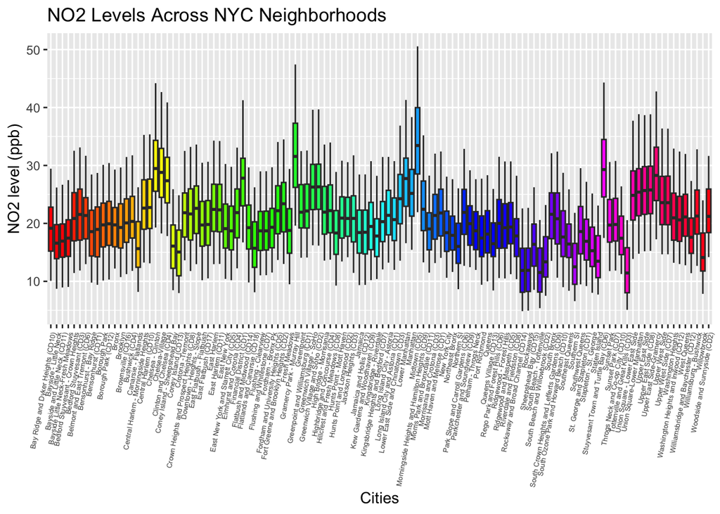

```r
no2_data <- filter(air_data, Name == "Nitrogen dioxide (NO2)" & Measure.Info == "ppb")

ggplot(no2_data, aes(x = Geo.Place.Name, y = Data.Value)) +
  geom_boxplot(fill = rainbow(length(unique(no2_data$Geo.Place.Name)))) +
  labs(x = "Cities",
       y = "NO2 level (ppb)",
       title = "NO2 Levels Across NYC Neighborhoods") +
  theme(axis.text.x = element_text(angle = 80, hjust = 1, size = 5))
```

```r
data_df <- air_data |>
  group_by(Name) |>
  summarise(mean_value = mean(Data.Value, na.rm = TRUE)) |>
  arrange(desc(mean_value))

data_df
```

```
## # A tibble: 18 × 2
##    Name                                                   mean_value
##    <chr>                                                       <dbl>
##  1 Annual vehicle miles traveled                               73.4
##  2 Asthma emergency departments visits due to Ozone            71.9
##  3 Annual vehicle miles traveled (cars)                        67.8
##  4 Asthma emergency department visits due to PM2.5             65.9
##  5 Boiler Emissions- Total NOx Emissions                       53.8
##  6 Deaths due to PM2.5                                         46.1
##  7 Ozone (O3)                                                  30.8
##  8 Nitrogen dioxide (NO2)                                      20.4
##  9 Cardiovascular hospitalizations due to PM2.5 (age 40+)      16.8
## 10 Respiratory hospitalizations due to PM2.5 (age 20+)         13.4
## 11 Asthma hospitalizations due to Ozone                        12.2
## 12 Boiler Emissions- Total SO2 Emissions                       11.0
## 13 Fine particles (PM 2.5)                                      9.05
## 14 Cardiac and respiratory deaths due to Ozone                  4.97
## 15 Annual vehicle miles traveled (trucks)                       3.89
## 16 Outdoor Air Toxics - Formaldehyde                            2.26
## 17 Outdoor Air Toxics - Benzene                                 1.77
## 18 Boiler Emissions- Total PM2.5 Emissions                      1.37
```

### Statistical Analysis:

For the statistical analysis, I will perform a difference in means hypothesis test to determine whether the average NO2 levels in Upper West Side and Queens Village are significantly different. This type of analysis is appropriate because it compares the means of two independent groups using continuous numerical data.

**Difference in means - t test**

*Hypotheses*

$H_0$: $\mu_1$ = $\mu_2$ $H_a$: $\mu_d$ $\neq$ $\mu_2$

Where,

$\mu_1$ = mean NO2 level in “Upper West Side (CD7)” $\mu_2$ = mean NO2 level in “Queens Village (CD13)”

```r
upper_west <- filter(no2_data, Geo.Place.Name == "Upper West Side (CD7)")
head(upper_west)
```

```
##   Unique.ID Indicator.ID                   Name Measure Measure.Info
## 1    336741          375 Nitrogen dioxide (NO2)    Mean          ppb
## 2    412676          375 Nitrogen dioxide (NO2)    Mean          ppb
## 3    412677          375 Nitrogen dioxide (NO2)    Mean          ppb
## 4    825832          375 Nitrogen dioxide (NO2)    Mean          ppb
## 5    825830          375 Nitrogen dioxide (NO2)    Mean          ppb
## 6    825831          375 Nitrogen dioxide (NO2)    Mean          ppb
##   Geo.Type.Name Geo.Join.ID        Geo.Place.Name         Time.Period
## 1            CD         107 Upper West Side (CD7)      Winter 2014-15
## 2            CD         107 Upper West Side (CD7)      Winter 2015-16
## 3            CD         107 Upper West Side (CD7)         Summer 2016
## 4            CD         107 Upper West Side (CD7)      Winter 2021-22
## 5            CD         107 Upper West Side (CD7) Annual Average 2022
## 6            CD         107 Upper West Side (CD7)         Summer 2022
##   Start_Date Data.Value Message
## 1 12/01/2014   27.42000      NA
## 2 12/01/2015   26.43000      NA
## 3 06/01/2016   19.10000      NA
## 4 12/01/2021   22.07527      NA
## 5 01/01/2022   18.17030      NA
## 6 06/01/2022   14.66935      NA
```

```r
queens <- filter(no2_data, Geo.Place.Name == "Queens Village (CD13)")
head(queens)
```

```
##   Unique.ID Indicator.ID                   Name Measure Measure.Info
## 1    550154          375 Nitrogen dioxide (NO2)    Mean          ppb
## 2    741288          375 Nitrogen dioxide (NO2)    Mean          ppb
## 3    603095          375 Nitrogen dioxide (NO2)    Mean          ppb
## 4    741287          375 Nitrogen dioxide (NO2)    Mean          ppb
## 5    826072          375 Nitrogen dioxide (NO2)    Mean          ppb
## 6    826074          375 Nitrogen dioxide (NO2)    Mean          ppb
##   Geo.Type.Name Geo.Join.ID        Geo.Place.Name         Time.Period
## 1            CD         413 Queens Village (CD13) Annual Average 2017
## 2            CD         413 Queens Village (CD13) Annual Average 2021
## 3            CD         413 Queens Village (CD13) Annual Average 2018
## 4            CD         413 Queens Village (CD13)         Summer 2021
## 5            CD         413 Queens Village (CD13)      Winter 2021-22
## 6            CD         413 Queens Village (CD13) Annual Average 2022
##   Start_Date Data.Value Message
## 1 01/01/2017   16.49000      NA
## 2 01/01/2021   14.62481      NA
## 3 01/01/2018   16.26000      NA
## 4 06/01/2021   10.40210      NA
## 5 12/01/2021   18.77723      NA
## 6 01/01/2022   14.27801      NA
```

```r
t.test(upper_west$Data.Value, queens$Data.Value, alternative = "two.sided")
```

```
##
##  Welch Two Sample t-test
##
## data:  upper_west$Data.Value and queens$Data.Value
## t = 6.972, df = 85.681, p-value = 6.108e-10
## alternative hypothesis: true difference in means is not equal to 0
## 95 percent confidence interval:
##  5.068012 9.111167
## sample estimates:
## mean of x mean of y
##  24.06227  16.97268
```

### Conclusion and Future Directions:

The results of the Welch Two Sample t-test show a statistically significant difference in the mean NO2 levels between Upper West Side and Queens Village. The test indicated a t-value of 6.972 with approximately 85.68 degrees of freedom, and a p-value of 6.108e-10, which is much lower than 0.05. The 95% confidence interval for the difference in means ranges from 5.07 to 9.11, suggesting that, on average, the NO2 concentration in the Upper West Side is notably higher than in Queens Village. Specifically, the average NO2 level in the Upper West Side was 24.06 ppb, compared to 16.97 ppb in Queens Village.

These findings have important implications for public health and environmental justice. The significant difference in NO2 levels suggests that residents in the Upper West Side may be exposed to more traffic-related air pollution than those in Queens Village. This could reflect differences in urban layout, traffic density, or distance to major roadways. For future research, it would be valuable to expand the analysis to more neighborhoods and include variables such as traffic data, industrial activity, and population density. Additionally, conducting a time-series analysis could help determine whether these differences persist across seasons or years, which would provide information about long-term exposure patterns and policy intervention needs.

### References:

Bobbitt, Zach (2021). *How to Rotate Axis Labels in ggplot2 (With Examples)*. https://www.statology.org/rotate-axis-labels-ggplot2/. Accessed April 30, 2025. I used this website to research how to rotate the x-axis labels for my box plot.

NYC OpenData (2025). *Air Quality*. https://catalog.data.gov/dataset/air-quality. Accessed April 28, 2025.

Stack Overflow (2006). *Dynamically coloring boxplot in R* https://stackoverflow.com/questions/40005888/dynamically-coloring-boxplot-in-r. Accessed 30, 2025. I used this website to research how to add the rainbow effect to my box plot.